# Ridge and Lasso Regressions

## Installing Packages

**ISLR** is the package for the Hastie, Witten, James & Tibshirani textbook that contains the data set *Hitters* which we use for this example. In addition, **glmnet** is the package that includes ridge and lasso regression.

```r
  #install.packages("ISLR",repos = "http://cran.us.r-project.org")
  #install.packages("glmnet",repos = "http://cran.us.r-project.org")
  library(ISLR)
  library(glmnet)
  options(scipen=999)
```

## The *Hitters* Data Set

Here, we’re going to be working with data set *Hitters*, which is described in detail on pp. 7-8 of https://cran.r-project.org/web/packages/ISLR/ISLR.pdf. Let’s get the data set *Hitters* and look at the first few rows:

```r
  fix(Hitters)
  head(Hitters)
```

```
##                   AtBat Hits HmRun Runs RBI Walks Years CAtBat CHits CHmRun
## -Andy Allanson      293   66     1   30  29    14     1    293    66      1
## -Alan Ashby         315   81     7   24  38    39    14   3449   835     69
## -Alvin Davis        479  130    18   66  72    76     3   1624   457     63
## -Andre Dawson       496  141    20   65  78    37    11   5628  1575    225
## -Andres Galarraga   321   87    10   39  42    30     2    396   101     12
## -Alfredo Griffin    594  169     4   74  51    35    11   4408  1133     19
##                   CRuns CRBI CWalks League Division PutOuts Assists Errors
## -Andy Allanson       30   29     14      A        E     446      33     20
## -Alan Ashby         321  414    375      N        W     632      43     10
## -Alvin Davis        224  266    263      A        W     880      82     14
## -Andre Dawson       828  838    354      N        E     200      11      3
## -Andres Galarraga    48   46     33      N        E     805      40      4
## -Alfredo Griffin    501  336    194      A        W     282     421     25
##                   Salary NewLeague
## -Andy Allanson        NA         A
## -Alan Ashby        475.0         N
## -Alvin Davis       480.0         A
## -Andre Dawson      500.0         N
## -Andres Galarraga   91.5         N
## -Alfredo Griffin   750.0         A
```

There are a total of 322 observations and 20 variables in the data set, as can be seen with the **dim** command.

```r
dim(Hitters)
```

```
## [1] 322  20
```

Now, let’s clean the data: the command below tells us that there are 59 observations where the DV *Salary* is missing.

```r
sum(is.na(Hitters$Salary))
```

```
## [1] 59
```

Let’s remove these 59 observations from the data set *Hitters*

```r
Hitters=na.omit(Hitters)
```

Now, there are 263 observations in the data set *Hitters*:

```r
dim(Hitters)
```

```
## [1] 263  20
```

```r
sum(is.na(Hitters))
```

```
## [1] 0
```

## Preparing the Data for Ridge and Lasso Regression

The syntax for running Ridge and Lasso regression is a little different than the syntax for running OLS regression. Here, we need a matrix of predictors (let’s call it x) and a vector (i.e., n x 1 matrix) containing the values of the dependent variable.

Keep in mind that the commands below automatically standardize the variables before running the Ridge/Lasso regressions.

Let’s create a matrix of predictor variables, called *x*. Here, we are simply removing the variable *Salary* from the data set *Hitters*.

```r
x=model.matrix(Salary~.,Hitters)[,-1]
head(x)
```

```
##                   AtBat Hits HmRun Runs RBI Walks Years CAtBat CHits CHmRun
## -Alan Ashby         315   81     7   24  38    39    14   3449   835     69
## -Alvin Davis        479  130    18   66  72    76     3   1624   457     63
## -Andre Dawson       496  141    20   65  78    37    11   5628  1575    225
## -Andres Galarraga   321   87    10   39  42    30     2    396   101     12
## -Alfredo Griffin    594  169     4   74  51    35    11   4408  1133     19
## -Al Newman          185   37     1   23   8    21     2    214    42      1
##                   CRuns CRBI CWalks LeagueN DivisionW PutOuts Assists Errors
## -Alan Ashby         321  414    375       1         1     632      43     10
## -Alvin Davis        224  266    263       0         1     880      82     14
## -Andre Dawson       828  838    354       1         0     200      11      3
## -Andres Galarraga    48   46     33       1         0     805      40      4
## -Alfredo Griffin    501  336    194       0         1     282     421     25
## -Al Newman           30    9     24       1         0      76     127      7
##                   NewLeagueN
## -Alan Ashby                1
## -Alvin Davis               0
## -Andre Dawson              1
## -Andres Galarraga          1
## -Alfredo Griffin           0
## -Al Newman                 0
```

Below, we generate the vector *y*, which is simply the dependent variable, *Salary*.

```r
y=Hitters$Salary
head(y)
```

```
## [1] 475.0 480.0 500.0  91.5 750.0  70.0
```

## Preparing Values of Lambda (Tuning Parameter)

Let’s generate a sequence of 100 values which we call *grid*. Basically, *grid* is a sequence which starts with 10^10 and goes down to 10^-2 (0.01). (The exponents go down by 0.121212 each time). These will be values used for lambda in the Ridge and Lasso regressions below.

In other words, values of lambda will be:

| Order in Sequence | Calculated Lambda |
| --- | --- |
| 1st | 10^(10-0.12121212*0) = 10^(10-0) = 10^10 |
| 2nd | 10^(10-0.12121212*1) |
| 3rd | 10^(10-0.12121212*2) |
| 4th | 10^(10-0.12121212*3) |
| … | … |
| 100th : | 10^(10-0.12121212*99) = 10^(10-12) = 10^(-2) |

E.g, the 50th value of lambda = 10^(10-0.12121212*49) = 11497.57

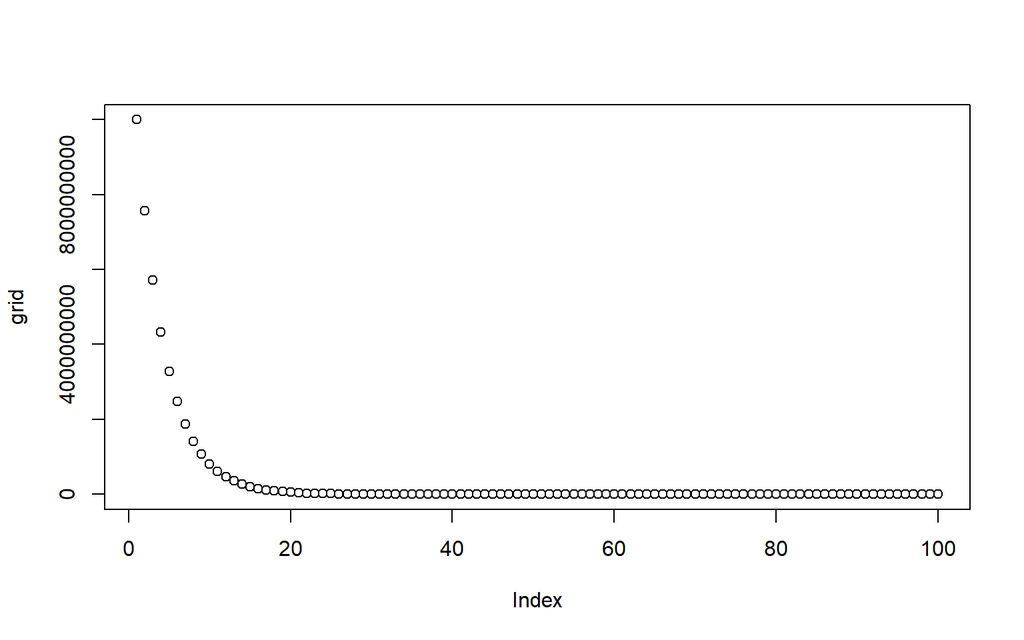

```r
grid=10^seq(10,-2,length=100)
plot(grid)
```

## Ridge Regression

Note that **alpha = 0** indicates that we run Ridge regression, and **alpha = 1** indicates we run Lasso. Here we are running Ridge Regression.

```r
ridge.mod=glmnet(x,y,alpha=0,lambda=grid)
```

Looking at the dimensions of the coefficient matrix. Here, there will be 20 rows (for the 19 predictors and one intercept term) and 100 columns (for the 100 different values of lambda).

```r
dim(coef(ridge.mod))
```

```
## [1]  20 100
```

```r
#Printing values of lambda
```

We will then print the 1st, 50th and 100th value of lambda, and the corresponding Beta coefficients.

```r
cbind(ridge.mod$lambda[1], ridge.mod$lambda[50], ridge.mod$lambda[100])
```

```
##             [,1]     [,2] [,3]
## [1,] 10000000000 11497.57 0.01
```

```r
cbind(coef(ridge.mod)[,1], coef(ridge.mod)[,50], coef(ridge.mod)[,100])
```

```
##                            [,1]          [,2]          [,3]
## (Intercept) 535.925693520897084 407.356050200  164.11321606
## AtBat         0.000000054434665   0.036957182   -1.97386151
## Hits          0.000000197458863   0.138180344    7.37772270
## HmRun         0.000000795652308   0.524629976    3.93660219
## Runs          0.000000333917810   0.230701523   -2.19873625
## RBI           0.000000352722151   0.239841459   -0.91623008
## Walks         0.000000415132259   0.289618741    6.20037718
## Years         0.000001697711384   1.107702929   -3.71403424
## CAtBat        0.000000004673743   0.003131815   -0.17510063
## CHits         0.000000017200708   0.011653637    0.21132772
## CHmRun        0.000000129717067   0.087545670    0.05629004
## CRuns         0.000000034508457   0.023379882    1.36605490
## CRBI          0.000000035613483   0.024138320    0.70965516
## CWalks        0.000000037678772   0.025015421   -0.79582173
## LeagueN      -0.000000580026254   0.085028114   63.40493257
## DivisionW    -0.000007807263348  -6.215440973 -117.08243713
## PutOuts       0.000000021802880   0.016482577    0.28202541
## Assists       0.000000003561198   0.002612988    0.37318482
## Errors       -0.000000016604602  -0.020502690   -3.42400281
## NewLeagueN   -0.000000115228775   0.301433531  -25.99081928
```

When lambda goes up, the magnitude of the coefficients goes down to 0. We can see that when lambda is very high (10^10), the intercept term is essentially the mean of the dependent variable. This is because when variables are centered (or standardized), the intercept is interpreted as the average value of the dependent variable when all predictors are 0.

```r
mean(y)
```

```
## [1] 535.9259
```

We can look at the magnitude of coefficients by looking at the square root of the sum of squared coefficients, which is called **l2 norm**. Below, let’s calculate the **l2 norm** when lambda is 11497.57 (value in the 50th column). We get 6.36.

```r
sqrt(sum(coef(ridge.mod)[-1,50]^2))    ##-1 indicates that we are ignoring the first coefficient (i.e., the intercept term) in the calculations of l2 norm.
```

```
## [1] 6.360612
```

## Training and Validation

We now split the samples into a training set and a test set in order to estimate the test error of ridge regression and the lasso. Here, we randomly choose a subset of numbers between 1 and n; these can then be used as the indices for the training observations.

We first set a random seed so that the results obtained will be reproducible.

```r
set.seed(1)
```

The Command *sample* takes a sample of the specified size from the elements of x The data set *train* selects observations which go into the training data set. Here, the number of rows (observations) in our data set can be calculated with the command *nrow()*.; if we want to take half of the observations into the training data set, we specify that with the *nrow(x)/2* argument.

```r
train=sample(1:nrow(x), nrow(x)/2)
```

This gives the IDs of observations in the training data set.

```r
train
```

```
##   [1] 167 129 187  85  79 213  37 105 217 110 229 165  34 106 126  89 172 207
##  [19]  33  84 163  70  74  42 166 111 148 156  20  44 121  87 242 233  40 247
##  [37]  25 119 198 122  39 179 240 134  24 160  14 130  45 146  22 206 193 115
##  [55] 104 231 208 209 103  75  13 253 176 248  23 254 244 205  29 141 150 236
##  [73] 108  48 245 215 149  31 102 145  73 232  83 118  90 190 107  64 196  60
##  [91]  51 251 138 262  43  26 143 195 152 178 223 219 202 181 222 169   1 239
## [109]  78 211 246  28 116 257  61 113  86  71 225  99 173 234  49 256 174 194
## [127]  50 135 238 235 230
```

All the observations that aren’t in the train (training) data are in the test data.

```r
test=(-train)
```

Here, y[test] are the y values in the test data set. Similarly, y[train] are the y values in the training data set. We can print them to look at the values.

```r
y[test]
```

```
##   [1]  480.000  500.000   91.500  750.000   70.000  100.000   75.000 1100.000
##   [9]  517.143  512.500  550.000  775.000  175.000  135.000  100.000  115.000
##  [17]  776.667  110.000  850.000   67.500  215.000  247.500  875.000  675.000
##  [25]   90.000  275.000  105.000  320.000  850.000  535.000  933.333  850.000
##  [33]  210.000  325.000 1975.000 1900.000 1041.667  110.000  260.000  475.000
##  [41]  431.500  145.000  490.000 2460.000 1175.000   70.000 1500.000  700.000
##  [49]  733.333  200.000  400.000  400.000  737.500  500.000  600.000  662.500
##  [57]  750.000  297.500  165.000  773.333  275.000  365.000  100.000  600.000
##  [65]  200.000  657.000 2412.500  250.000  300.000  110.000  825.000  630.000
##  [73]   86.500 1000.000 1800.000  737.500  125.000  300.000  202.500  525.000
##  [81]  265.000  787.500  587.500  145.000  420.000  575.000  780.000  150.000
##  [89]   68.000  670.000  175.000  120.000  210.000  350.000  200.000 1940.000
##  [97]  700.000  750.000  450.000 1260.000  750.000  580.000  130.000  215.000
## [105]  560.000 1670.000  487.500  500.000  250.000  190.000  740.000  140.000
## [113]  740.000  341.667  100.000   90.000  155.000 1450.000  150.000  105.000
## [121]  740.000  920.000  245.000  500.000  277.500  160.000  550.000  165.000
## [129]  700.000  875.000  385.000 1000.000
```

```r
y[train]
```

```
##   [1]  650.000  155.000  172.000  215.000  750.000  250.000  815.000   90.000
##   [9]  140.000  250.000  350.000  700.000  305.000 1237.500   75.000  535.000
##  [17]  137.000  750.000  180.000 1925.571   90.000 1220.000 1861.460  415.000
##  [25]  550.000 1300.000  365.000  800.000  600.000  416.667  277.500  155.000
##  [33]  286.667  940.000 1200.000  425.000  625.000  110.000  400.000   80.000
##  [41]   70.000  240.000  185.000  195.000  750.000   75.000  240.000  640.000
##  [49] 1350.000  725.000  765.000  450.000  450.000  775.000  175.000  530.000
##  [57]   70.000  875.000   87.500  300.000  700.000 1300.000  140.000  900.000
##  [65]  708.333  525.000  235.000  400.000  300.000 1310.000 1183.333  250.000
##  [73]  100.000  230.000 1150.000   97.500   75.000   90.000  325.000 1043.333
##  [81]  595.000  341.667  385.000   95.000  362.500  190.000  430.000  600.000
##  [89] 1050.000  275.000   75.000  750.000 1300.000  960.000  340.000  900.000
##  [97]  625.000  250.000  225.000  800.000  135.000 1000.000  425.000  175.000
## [105]  200.000  100.000  475.000  925.000  375.000  191.000  160.000  612.500
## [113]  850.000  120.000  450.000 1008.333  900.000   70.000  475.000  950.000
## [121] 2127.333  350.000  225.000 1600.000  875.000  300.000  950.000  450.000
## [129]  425.000  326.667   90.000
```

Let’s call the y-values in the test data set y.test.

```r
y.test=y[test]
```

Fit on training data set

```r
ridge.mod=glmnet(x[train,],y[train],alpha=0,lambda=grid, thresh=1e-12)
```

Get y-hats for test data set Here, the s=4 indicates that lambda=4 (s=lambda here)

```r
ridge.pred=predict(ridge.mod,s=4,newx=x[test,])
head(ridge.pred)     #these are the y-hats for the test data set
```

```
##                          s1
## -Alvin Davis       735.6990
## -Andre Dawson     1184.6088
## -Andres Galarraga  525.5162
## -Alfredo Griffin   379.5287
## -Al Newman         338.1078
## -Argenis Salazar    76.2617
```

Let’s calculate the MSE of the Ridge regression in the test data set. Here, it is 142199.2

```r
test.mse=mean((ridge.pred-y.test)^2)
test.mse
```

```
## [1] 142199.2
```

```r
test.rmse = sqrt(test.mse)
test.rmse
```

```
## [1] 377.093
```

What if we choose a very large value of lambda? Let’s say, we pick lambda of 10^10 (which we write in R as 1e10. With that value of lambda, all the coefficients will be very close to (i.e., essentially exactly) 0, indicating that what we will be fitting an OLS model that ONLY includes the intercept!

```r
ridge.pred=predict(ridge.mod,s=1e10,newx=x[test,])
```

Note that the predicted values for each hitter is essentially the same (these are the intercept values)

```r
head(ridge.pred)
```

```
##                         s1
## -Alvin Davis      531.8654
## -Andre Dawson     531.8655
## -Andres Galarraga 531.8653
## -Alfredo Griffin  531.8654
## -Al Newman        531.8652
## -Argenis Salazar  531.8652
```

Let’s look at the MSE. Here, it is 224669.8, which is higher than 142199.2. This tells us that running the intercept-only model (i.e., the ridge regression with a very high lambda) yields a higher (i.e., worse) MSE than running the ridge regression where lambda is 4, as above.

```r
test.mse=mean((ridge.pred-y.test)^2)
test.mse
```

```
## [1] 224669.8
```

```r
test.rmse = sqrt(test.mse)
test.rmse
```

```
## [1] 473.9935
```

```r
ridge.pred=predict(ridge.mod,s=0,newx=x[test,])
```

MSE of the OLS model in the test data set is 167789.8 (still higher than the MSE of the ridge regression when lambda = 4, as we saw above (there, recall that MSE was 142199.2)).

```r
test.mse=mean((ridge.pred-y.test)^2)
test.mse
```

```
## [1] 167789.8
```

```r
test.rmse = sqrt(test.mse)
test.rmse
```

```
## [1] 409.6215
```

So we have the following MSEs and RMSEs:

| Lambda | Test MSE | Test RMSE | Notes |
| --- | --- | --- | --- |
| 4 | 142199.2 | 377.1 |  |
| 10^10 | 224669.8 | 474.0 | Essentially this is the intercept-only OLS model |
| 0 | 167789.8 | 409.6 | Essentially this is the original OLS model |

In general, if we want to fit an (unpenalized) least squares model where lambda is 0, then we should use the lm() function, since that function provides more useful outputs, such as standard errors and p-values for the coefficients.

```r
lm.output<-lm(y~x, subset=train)
predict(ridge.mod,s=0,type="coefficients")[1:20,]
```

```
##  (Intercept)        AtBat         Hits        HmRun         Runs          RBI
##  274.2089049   -0.3699455   -1.5370022    5.9129307    1.4811980    1.0772844
##        Walks        Years       CAtBat        CHits       CHmRun        CRuns
##    3.7577989  -16.5600387   -0.6313336    3.1115575    3.3297885   -0.9496641
##         CRBI       CWalks      LeagueN    DivisionW      PutOuts      Assists
##   -0.5694414    0.3300136  118.4000592 -144.2867510    0.1971770    0.6775088
##       Errors   NewLeagueN
##   -4.6833775  -70.1616132
```

As mentioned above, We can get more useful output with the lm command if we want to set lambda to 0.

```r
summary(lm.output)
```

```
##
## Call:
## lm(formula = y ~ x, subset = train)
##
## Residuals:
##     Min      1Q  Median      3Q     Max
## -755.40 -172.21  -16.12  148.81 1709.58
##
## Coefficients:
##              Estimate Std. Error t value Pr(>|t|)
## (Intercept)  274.0145   125.3304   2.186   0.0309 *
## xAtBat        -0.3521     0.9547  -0.369   0.7130
## xHits         -1.6377     3.7435  -0.437   0.6626
## xHmRun         5.8145     9.5466   0.609   0.5437
## xRuns          1.5424     4.5241   0.341   0.7338
## xRBI           1.1243     3.8265   0.294   0.7694
## xWalks         3.7287     2.6005   1.434   0.1544
## xYears       -16.3773    17.4006  -0.941   0.3487
## xCAtBat       -0.6412     0.2499  -2.565   0.0116 *
## xCHits         3.1632     1.1572   2.733   0.0073 **
## xCHmRun        3.4008     2.9882   1.138   0.2575
## xCRuns        -0.9739     1.1832  -0.823   0.4122
## xCRBI         -0.6005     1.1839  -0.507   0.6130
## xCWalks        0.3379     0.5657   0.597   0.5515
## xLeagueN     119.1486   117.7810   1.012   0.3139
## xDivisionW  -144.0831    55.8401  -2.580   0.0112 *
## xPutOuts       0.1976     0.1078   1.833   0.0694 .
## xAssists       0.6804     0.3054   2.228   0.0279 *
## xErrors       -4.7128     6.4677  -0.729   0.4677
## xNewLeagueN  -71.0951   117.4263  -0.605   0.5461
## ---
## Signif. codes:  0 '***' 0.001 '**' 0.01 '*' 0.05 '.' 0.1 ' ' 1
##
## Residual standard error: 297 on 111 degrees of freedom
## Multiple R-squared:  0.5862, Adjusted R-squared:  0.5154
## F-statistic: 8.276 on 19 and 111 DF,  p-value: 0.00000000000007206
```

In general, instead of arbitrarily choosing lambda = 4, it would be better to use cross-validation to choose the tuning parameter lambda. We can do this using the built-in cross-validation function, cv.glmnet(). By default, the function cv.glmnet() performs ten-fold cross-validation on the training data set, though this can be changed using the argument nfolds. Note that we set a random seed first so our results will be reproducible, since the choice of the cross-validation folds is random.

```r
set.seed(1)
cv.out=cv.glmnet(x[train,],y[train],alpha=0, nfolds=10)
```

Let’s plot the log(lambda) against the MSE in the validation data set

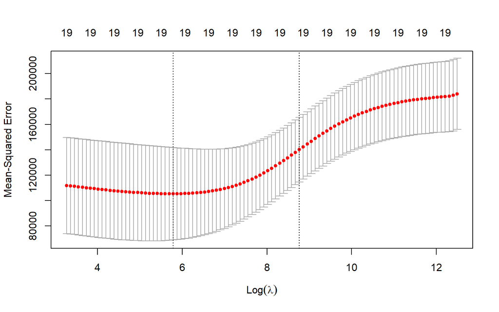

```r
plot(cv.out)
```

Let’s calculate the value of lambda for which the MSE is minimized using cross-validation

```r
bestlam=cv.out$lambda.min
```

We can see that this value of lambda is about 326.0828 (when log(lambda) = 5.79). Next, we can see if Ridge regression when lambda is 326.0828 yields lower test MSE than OLS regression (i.e., ridge regression when lambda = 0).

```r
bestlam
```

```
## [1] 326.0828
```

The test MSE associated with this level of lambda (i.e., when s=bestlam) is calculated below. We see that this MSE is 139856.6, and it’s lower than the OLS MSE (which again, is 167789.8)

```r
ridge.pred=predict(ridge.mod,s=bestlam,newx=x[test,])
mse.bestlam <- mean((ridge.pred-y.test)^2)
rmse.bestlam <- sqrt(mse.bestlam)
mse.bestlam
```

```
## [1] 139856.6
```

```r
rmse.bestlam
```

```
## [1] 373.9741
```

# So we have the following MSEs and RMSEs:

| Lambda | Test MSE | Test RMSE | Notes |
| --- | --- | --- | --- |
| 4 | 142199.2 | 377.1 |  |
| 10^10 | 224669.8 | 474.0 | Essentially this is the intercept-only OLS model |
| 0 | 167789.8 | 409.6 | Essentially this is the original OLS model |
| 326.0828 | 139856.6 | 374.0 | This is the lambda chosen by cross-validation |

Finally, we refit our ridge regression model on the full data set, using the value of lambda (bestlam=326.0828) chosen by cross-validation, and examine the coefficient estimates.

```r
out=glmnet(x,y,alpha=0)
```

As expected, none of the coefficients are zero: Ridge regression does not perform variable selection! Note that variables DivisionW, LeagueN and NewLeagueN yield coefficients which are the largest in absolute value, indicating that they are among the most important predictors in the model.

```r
predict(out,type="coefficients",s=bestlam)[1:20,]
```

```
##  (Intercept)        AtBat         Hits        HmRun         Runs          RBI
##  15.44383120   0.07715547   0.85911582   0.60103106   1.06369007   0.87936105
##        Walks        Years       CAtBat        CHits       CHmRun        CRuns
##   1.62444617   1.35254778   0.01134999   0.05746654   0.40680157   0.11456224
##         CRBI       CWalks      LeagueN    DivisionW      PutOuts      Assists
##   0.12116504   0.05299202  22.09143197 -79.04032656   0.16619903   0.02941950
##       Errors   NewLeagueN
##  -1.36092945   9.12487765
```

Compare these results to the OLS regression results. Are any of these predictors even significant in the OLS regression?

```r
lm.results=lm(y~x)
summary(lm.results)
```

```
##
## Call:
## lm(formula = y ~ x)
##
## Residuals:
##     Min      1Q  Median      3Q     Max
## -907.62 -178.35  -31.11  139.09 1877.04
##
## Coefficients:
##               Estimate Std. Error t value Pr(>|t|)
## (Intercept)  163.10359   90.77854   1.797 0.073622 .
## xAtBat        -1.97987    0.63398  -3.123 0.002008 **
## xHits          7.50077    2.37753   3.155 0.001808 **
## xHmRun         4.33088    6.20145   0.698 0.485616
## xRuns         -2.37621    2.98076  -0.797 0.426122
## xRBI          -1.04496    2.60088  -0.402 0.688204
## xWalks         6.23129    1.82850   3.408 0.000766 ***
## xYears        -3.48905   12.41219  -0.281 0.778874
## xCAtBat       -0.17134    0.13524  -1.267 0.206380
## xCHits         0.13399    0.67455   0.199 0.842713
## xCHmRun       -0.17286    1.61724  -0.107 0.914967
## xCRuns         1.45430    0.75046   1.938 0.053795 .
## xCRBI          0.80771    0.69262   1.166 0.244691
## xCWalks       -0.81157    0.32808  -2.474 0.014057 *
## xLeagueN      62.59942   79.26140   0.790 0.430424
## xDivisionW  -116.84925   40.36695  -2.895 0.004141 **
## xPutOuts       0.28189    0.07744   3.640 0.000333 ***
## xAssists       0.37107    0.22120   1.678 0.094723 .
## xErrors       -3.36076    4.39163  -0.765 0.444857
## xNewLeagueN  -24.76233   79.00263  -0.313 0.754218
## ---
## Signif. codes:  0 '***' 0.001 '**' 0.01 '*' 0.05 '.' 0.1 ' ' 1
##
## Residual standard error: 315.6 on 243 degrees of freedom
## Multiple R-squared:  0.5461, Adjusted R-squared:  0.5106
## F-statistic: 15.39 on 19 and 243 DF,  p-value: < 0.00000000000000022
```

## Lasso Regression

Here, alpha is set to 1 to indicate that we’re running lasso regression (and not ridge)

```r
lasso.mod=glmnet(x[train,],y[train],alpha=1,lambda=grid)
```

Again, let’s assess which model is better as per cross-validation MSE

```r
set.seed(1)
cv.out=cv.glmnet(x[train,],y[train],alpha=1)
```

Here, we’re seeing a plot of logged lambda against MSE.

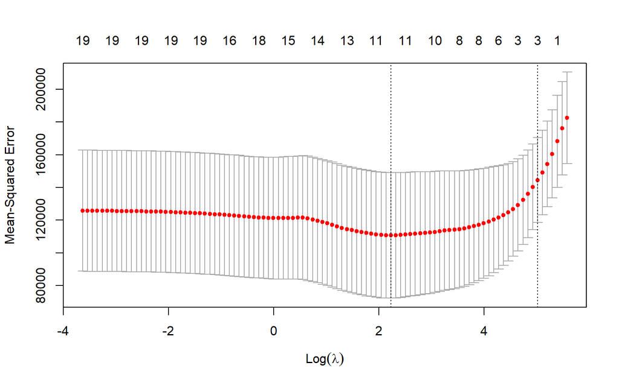

```r
plot(cv.out)
```

Let’s identify the best lambda and calculate the best MSE associated with the best lambda from cross-validation

```r
bestlam=cv.out$lambda.min
bestlam
```

```
## [1] 9.286955
```

Here, this “best” lambda is 9.286955 (corresponding to log(lambda) = 2.23)

Let’s get the y-hats (lasso.pred values) with the optimal level of lambda in the test data

```r
lasso.pred=predict(lasso.mod,s=bestlam,newx=x[test,])
```

Here, the MSE associated with the best lambda is 143673.6 (better than the OLS MSE of 167789.8 but worse than the ridge MSE of 139856.6)

```r
mse.bestlam.lasso <- mean((lasso.pred-y.test)^2)
rmse.bestlam.lasso <- sqrt(mse.bestlam.lasso)
mse.bestlam.lasso
```

```
## [1] 143673.6
```

```r
rmse.bestlam.lasso
```

```
## [1] 379.043
```

Here’s the summary:

| Model | Lambda | Test MSE | Test RMSE | Notes |
| --- | --- | --- | --- | --- |
| OLS/Ridge/Lasso | 0 | 167789.8 | 409.6 | This is the OLS model |
| OLS/Ridge/Lasso | 10^10 | 224669.8 | 474.0 | Intercept-only OLS model |
| Ridge | 4 | 142199.2 | 377.1 | Arbitrarily chosen level of lambda |
| Ridge | 326.0828 | 139856.6 | 374.0 | Lambda chosen by cross-validation in Ridge |
| Lasso | 9.286955 | 143673.6 | 379.0 | Lambda chosen by cross-validation in Lasso |

However, the Lasso has a substantial advantage over ridge regression in that the resulting coefficient estimates are sparse. Here we see that 8 of the 19 coefficient estimates are exactly zero. So the lasso model with lambda chosen by cross-validation contains only 11 variables.

Refitting model on full data set

```r
out=glmnet(x,y,alpha=1,lambda=grid)
lasso.coef=predict(out,type="coefficients",s=bestlam)[1:20,]
lasso.coef
```

```
##   (Intercept)         AtBat          Hits         HmRun          Runs
##    1.27479059   -0.05497143    2.18034583    0.00000000    0.00000000
##           RBI         Walks         Years        CAtBat         CHits
##    0.00000000    2.29192406   -0.33806109    0.00000000    0.00000000
##        CHmRun         CRuns          CRBI        CWalks       LeagueN
##    0.02825013    0.21628385    0.41712537    0.00000000   20.28615023
##     DivisionW       PutOuts       Assists        Errors    NewLeagueN
## -116.16755870    0.23752385    0.00000000   -0.85629148    0.00000000
```

Let’s print out the predictors in the Lasso model which have nonzero coefficients when lambda is set to bestlam

```r
lasso.coef[lasso.coef!=0]
```

```
##   (Intercept)         AtBat          Hits         Walks         Years
##    1.27479059   -0.05497143    2.18034583    2.29192406   -0.33806109
##        CHmRun         CRuns          CRBI       LeagueN     DivisionW
##    0.02825013    0.21628385    0.41712537   20.28615023 -116.16755870
##       PutOuts        Errors
##    0.23752385   -0.85629148
```

Now, let’s rerun the OLS model with these same 11 predictors. We note that some of them aren’t even statistically significant, and that the OLS coefficient estimates are pretty different than the lasso coefficient estimates - that is because the lasso estimates are biased.

```r
lasso.lm = lm(y~Hitters$AtBat + Hitters$Hits + Hitters$Walks + Hitters$Years + Hitters$CHmRun + Hitters$CRuns + Hitters$CRBI + Hitters$League + Hitters$Division + Hitters$PutOuts + Hitters$Errors)
summary(lasso.lm)
```

```
##
## Call:
## lm(formula = y ~ Hitters$AtBat + Hitters$Hits + Hitters$Walks +
##     Hitters$Years + Hitters$CHmRun + Hitters$CRuns + Hitters$CRBI +
##     Hitters$League + Hitters$Division + Hitters$PutOuts + Hitters$Errors)
##
## Residuals:
##     Min      1Q  Median      3Q     Max
## -915.78 -180.32  -30.63  145.30 1973.34
##
## Coefficients:
##                     Estimate Std. Error t value  Pr(>|t|)
## (Intercept)        159.94390   88.78150   1.802  0.072817 .
## Hitters$AtBat       -1.92711    0.55804  -3.453  0.000650 ***
## Hitters$Hits         7.54349    1.73852   4.339 0.0000208 ***
## Hitters$Walks        3.15576    1.26749   2.490  0.013430 *
## Hitters$Years      -18.52875   10.39666  -1.782  0.075928 .
## Hitters$CHmRun       0.18395    0.83247   0.221  0.825295
## Hitters$CRuns        0.38700    0.22098   1.751  0.081122 .
## Hitters$CRBI         0.48424    0.36663   1.321  0.187771
## Hitters$LeagueN     34.79937   41.43369   0.840  0.401774
## Hitters$DivisionW -118.99843   39.98939  -2.976  0.003208 **
## Hitters$PutOuts      0.26517    0.07611   3.484  0.000583 ***
## Hitters$Errors       0.09014    3.38713   0.027  0.978790
## ---
## Signif. codes:  0 '***' 0.001 '**' 0.01 '*' 0.05 '.' 0.1 ' ' 1
##
## Residual standard error: 319.4 on 251 degrees of freedom
## Multiple R-squared:  0.5197, Adjusted R-squared:  0.4987
## F-statistic: 24.69 on 11 and 251 DF,  p-value: < 0.00000000000000022
```

But is OLS even appropriate here? Should we even be looking at statistical significance in OLS? For instance, what happens if we look at the Variance Inflation Factor? As we can see, the VIF is huge for some predictors, meaning that we have severe multicollinearity, which can affect the statistical significance.

```r
#install.packages("car")
library(car)
vif(lasso.lm)
```

```
##    Hitters$AtBat     Hitters$Hits    Hitters$Walks    Hitters$Years
##        17.353288        15.805338         1.945959         6.378525
##   Hitters$CHmRun    Hitters$CRuns     Hitters$CRBI   Hitters$League
##        12.024251        13.756427        36.094825         1.102790
## Hitters$Division  Hitters$PutOuts   Hitters$Errors
##         1.030227         1.165751         1.285945
```

Again, the benefit of ridge and lasso regression over OLS are in terms of yielding a lower MSE in the test data set. But we should not be interpreting coefficients from ridge and lasso in the same way as in OLS.

Note that Ridge and Lasso regression don’t have the assumption of no multicollinearity, but these methods still have the assumptions of linearity, homoscedasticity, and independence of observations. These methods are also sensitive to outliers.